# Statistic1

2025-02-25

离散分布：两点分布，二项分布，泊松分布，超几何分布 连续分布：均匀分布，正态分布，指数分布，伽马分布

# 连续-分类变量分析

单样本 T 检验用于比较样本均值与已知总体均值之间的差异 前提条件: 样本数据服从正态分布（可以使用 Shapiro-Wilk 检验来判断样本数据是否服从正态分布）

```r
set.seed(123)
heights <- data.frame(height = c(rnorm(30, 170, 10), rnorm(30, 180, 10)),
                      group = rep(c(0, 1), each = 30))
heights
```

```
##      height group
## 1  164.3952     0
## 2  167.6982     0
## 3  185.5871     0
## 4  170.7051     0
## 5  171.2929     0
## 6  187.1506     0
## 7  174.6092     0
## 8  157.3494     0
## 9  163.1315     0
## 10 165.5434     0
## 11 182.2408     0
## 12 173.5981     0
## 13 174.0077     0
## 14 171.1068     0
```

[output cut: 46 more lines]

```r
treatment_group <- heights[heights$group == 1, 'height']
treatment_group
```

```
##  [1] 184.2646 177.0493 188.9513 188.7813 188.2158 186.8864 185.5392 179.3809
##  [9] 176.9404 176.1953 173.0529 177.9208 167.3460 201.6896 192.0796 168.7689
## [17] 175.9712 175.3334 187.7997 179.1663 182.5332 179.7145 179.5713 193.6860
## [25] 177.7423 195.1647 164.5125 185.8461 181.2385 182.1594
```

```r
t.test(treatment_group, mu = 175)
```

```
##
##  One Sample t-test
##
## data:  treatment_group
## t = 4.4489, df = 29, p-value = 0.0001169
## alternative hypothesis: true mean is not equal to 175
## 95 percent confidence interval:
##  178.6650 184.9018
## sample estimates:
## mean of x
##  181.7834
```

独立样本T检验用于比较两个独立样本的均值 前提：两个样本的数据都服从正态分布，且方差齐性（可以通过 Levene 检验或 Bartlett 检验来验证） car 包中有 leveneTest 函数

```r
control_group <- heights[heights$group == 0, 'height']
t.test(control_group, treatment_group)
```

```
##
##  Welch Two Sample t-test
##
## data:  control_group and treatment_group
## t = -5.2098, df = 56.559, p-value = 2.755e-06
## alternative hypothesis: true difference in means is not equal to 0
## 95 percent confidence interval:
##  -16.965426  -7.543416
## sample estimates:
## mean of x mean of y
##  169.5290  181.7834
```

ANOVA（方差分析）用于比较三个或更多独立组的均值 前提：各样本数据服从正态分布，且方差齐性

```r
set.seed(456)
data <- data.frame(score = c(rnorm(30, 80, 10), rnorm(30, 85, 10), rnorm(30, 90, 10)),
                   class = factor(rep(1:3, each = 30)))
anova_result <- aov(score ~ class, data = data)
summary(anova_result)
```

```
##             Df Sum Sq Mean Sq F value Pr(>F)
## class        2    707   353.5   3.383 0.0385 *
## Residuals   87   9093   104.5
## ---
## Signif. codes:  0 '***' 0.001 '**' 0.01 '*' 0.05 '.' 0.1 ' ' 1
```

当数据不满足正态分布时， 可以使用单样本 Wilcoxon 符号秩检验来替代单样本 T 检验，用于检验样本中位数是否等于某个已知值 [？伽马函数参数] [shape:gamma分布形状,alpha<1, pdf在x=0时有垂直渐进线，单调递减；alpha=1, 指数分布；alpha>1, 先上升后下降，但不对称] [rate:速率，控制分散程度和随机变量的平均大小，值越大，分布越集中]

```r
set.seed(789)
non_normal_data <-rgamma(30, shape = 2, rate = 1)

wilcox.test(non_normal_data, mu = 2)
```

```
##
##  Wilcoxon signed rank exact test
##
## data:  non_normal_data
## V = 80, p-value = 0.001131
## alternative hypothesis: true location is not equal to 2
```

Mann - Whitney U 检验 当两个独立样本不满足正态分布或方差齐性时， 可以使用 Mann - Whitney U 检验来替代独立样本 T 检验，用于比较两个独立样本的分布位置

```r
set.seed(1011)
group1 <- rgamma(20, shape = 2, rate = 1)
group2 <- rgamma(20, shape = 3, rate = 1)

wilcox.test(group1, group2)
```

```
##
##  Wilcoxon rank sum exact test
##
## data:  group1 and group2
## W = 76, p-value = 0.0005305
## alternative hypothesis: true location shift is not equal to 0
```

Kruskal - Wallis 检验 当多个独立样本不满足正态分布或方差齐性时，可以使用 Kruskal - Wallis 检验来替代 ANOVA，用于比较多个独立样本的分布位置

```r
set.seed(1213)
group_a <- rgamma(20, shape = 2, rate = 1)
group_b <- rgamma(20, shape = 3, rate = 1)
group_c <- rgamma(20, shape = 4, rate = 1)

non_normal_multi_data <- data.frame(value = c(group_a, group_b, group_c),
                                    group = factor(rep(c("A", "B", "C"), each = 20)))
kruskal.test(value ~ group, data = non_normal_multi_data,)
```

```
##
##  Kruskal-Wallis rank sum test
##
## data:  value by group
## Kruskal-Wallis chi-squared = 15.114, df = 2, p-value = 0.0005223
```

# 连续-连续变量分析

相关分析用于确定两个连续变量之间的线性关系。常用的相关系数有皮尔逊相关系数和斯皮尔曼相关系数 前提：皮尔逊相关系数要求两个变量都服从正态分布，而斯皮尔曼相关系数是基于数据的秩次，不要求数据服从正态分布

```r
set.seed(789)
heights_weights <- data.frame(height = rnorm(50, 170, 10),
                              weight = rnorm(50, 70, 15))
shapiro.test(heights_weights$height)
```

```
##
##  Shapiro-Wilk normality test
##
## data:  heights_weights$height
## W = 0.96807, p-value = 0.1929
```

```r
shapiro.test(heights_weights$weight)
```

```
##
##  Shapiro-Wilk normality test
##
## data:  heights_weights$weight
## W = 0.98958, p-value = 0.9359
```

```r
cor.test(heights_weights$height, heights_weights$weight, method = 'pearson')
```

```
##
##  Pearson's product-moment correlation
##
## data:  heights_weights$height and heights_weights$weight
## t = 0.023476, df = 48, p-value = 0.9814
## alternative hypothesis: true correlation is not equal to 0
## 95 percent confidence interval:
##  -0.2752189  0.2814706
## sample estimates:
##         cor
## 0.003388401
```

线性回归分析用于建立两个连续变量之间的线性关系模型，通过一个变量来预测另一个变量 前置检验：正态性检验、方差齐性检验（残差的方差齐性）和独立性检验（残差的独立性）

可使用 car 包中的 ncvTest() 函数对残差进行方差齐性检验 可通过绘制残差与观测值顺序的图来初步判断残差是否独立，也可使用 Durbin - Watson 检验来检验残差的自相关性 在 R 语言中，可使用 car 包中的 durbinWatsonTest() 函数 [？残差的自相关性 >0.05,通过检验]

```r
model <- lm(weight ~ height, data = heights_weights)
summary(model)
```

```
##
## Call:
## lm(formula = weight ~ height, data = heights_weights)
##
## Residuals:
##     Min      1Q  Median      3Q     Max
## -40.393 -11.302   1.239  10.875  34.230
##
## Coefficients:
##              Estimate Std. Error t value Pr(>|t|)
## (Intercept) 70.061527  40.758312   1.719   0.0921 .
## height       0.005668   0.241462   0.023   0.9814
## ---
## Signif. codes:  0 '***' 0.001 '**' 0.01 '*' 0.05 '.' 0.1 ' ' 1
##
## Residual standard error: 15.57 on 48 degrees of freedom
## Multiple R-squared:  1.148e-05,  Adjusted R-squared:  -0.02082
## F-statistic: 0.0005511 on 1 and 48 DF,  p-value: 0.9814
```

```r
library(car)
durbinWatsonTest(model)
```

```
##  lag Autocorrelation D-W Statistic p-value
##    1     -0.07067672      2.101706    0.69
##  Alternative hypothesis: rho != 0
```

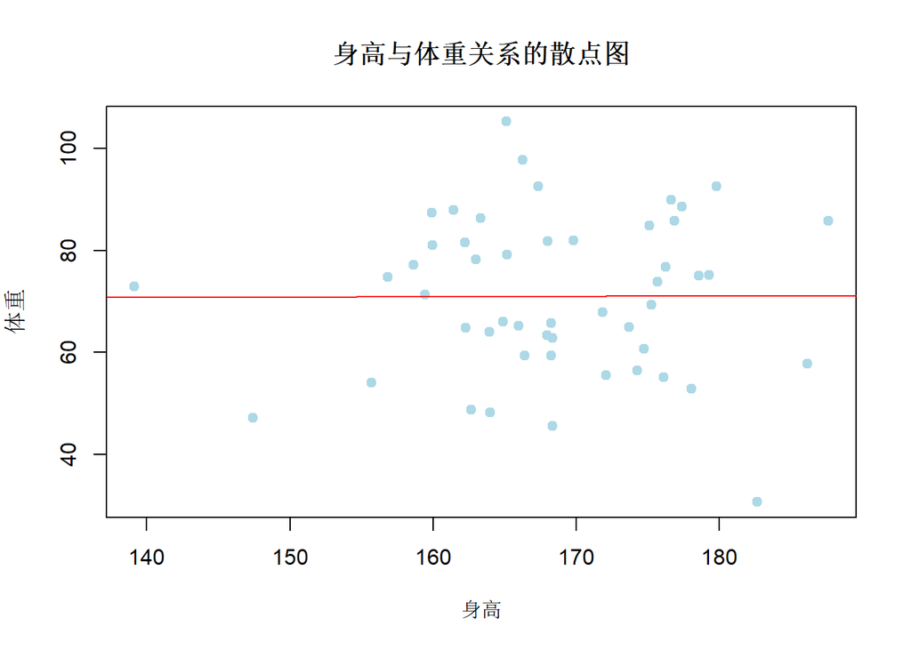

```r
plot(heights_weights$height, heights_weights$weight, main = '身高与体重关系的散点图',
     xlab = '身高', ylab = '体重', pch = 19, col = 'lightblue')
abline(model, col = 'red')
```

# 分类-分类变量分析

卡方检验用于检验分类变量之间的独立性 当列联表中单元格的期望频数小于 5 时，卡方检验的结果可能不准确，此时可以使用 Fisher 精确检验 [？期望频数, 样本量]

```r
set.seed(101112)
survey_data <- data.frame(smoker = factor(sample(c("yes", "no"), 50, replace = TRUE)),
                          disease = factor(sample(c("yes", "no"), 50, replace = TRUE)))
contingency_table <- table(survey_data$smoker, survey_data$disease)
chisq.test(contingency_table)
```

```
##
##  Pearson's Chi-squared test with Yates' continuity correction
##
## data:  contingency_table
## X-squared = 0, df = 1, p-value = 1
```

```r
fisher.test(contingency_table)
```

```
##
##  Fisher's Exact Test for Count Data
##
## data:  contingency_table
## p-value = 1
## alternative hypothesis: true odds ratio is not equal to 1
## 95 percent confidence interval:
##  0.297679 3.883990
## sample estimates:
## odds ratio
##    1.06799
```

# ANOVA 作图

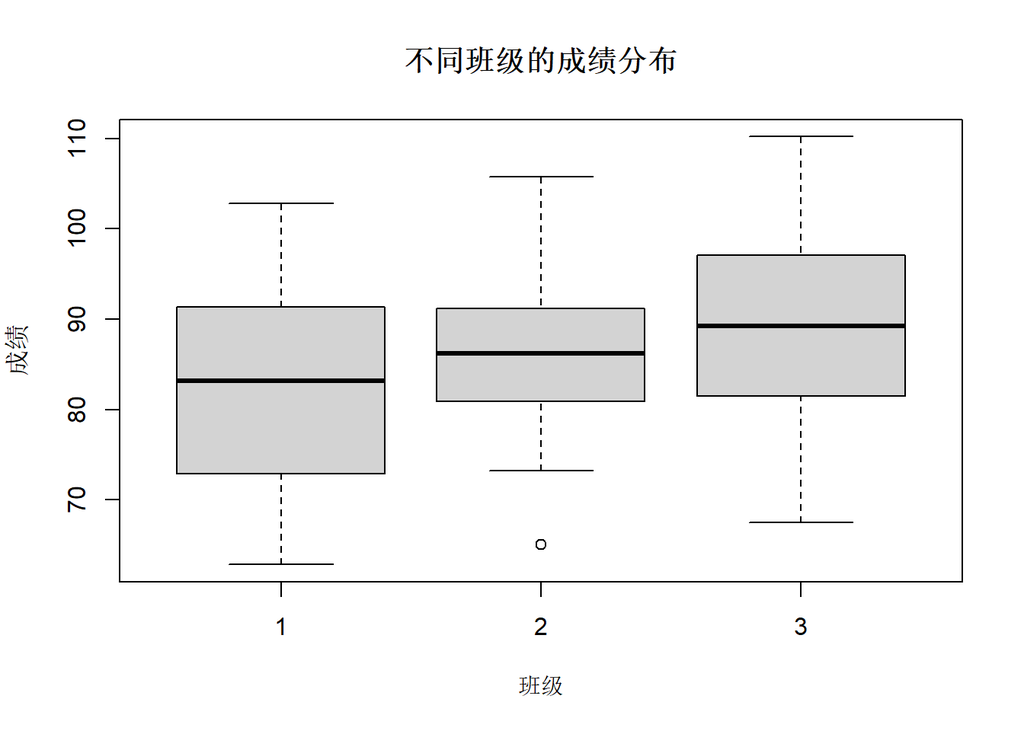

```r
boxplot(score ~ class, data = data, main = "不同班级的成绩分布", xlab = "班级", ylab = "成绩")
```

#相关分析作图

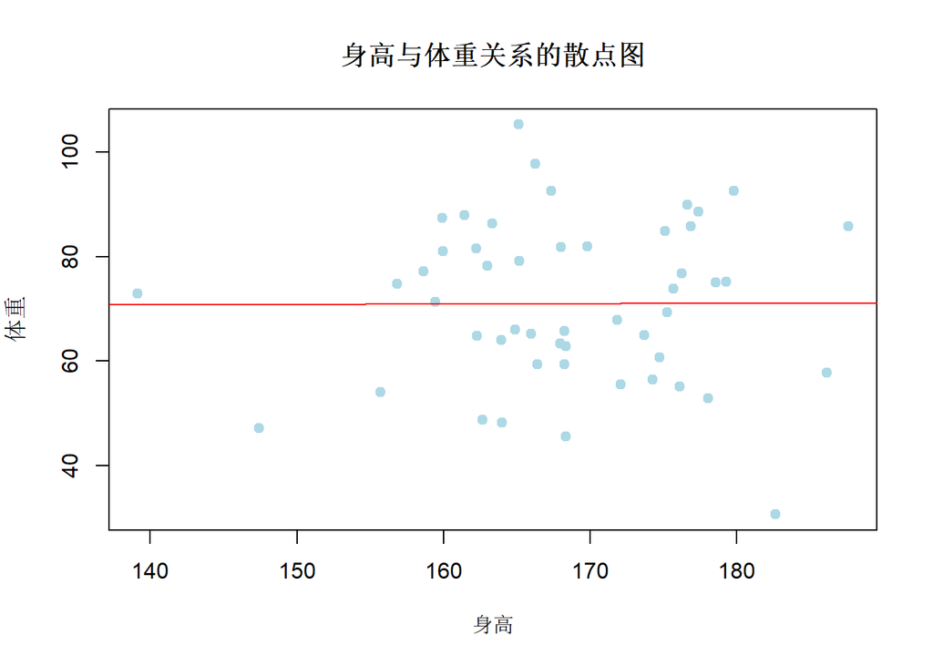

```r
plot(heights_weights$height, heights_weights$weight, main = '身高与体重关系的散点图',
     xlab = '身高', ylab = '体重', pch = 19, col = 'lightblue')
abline(model, col = 'red')
```

#卡方检验作图

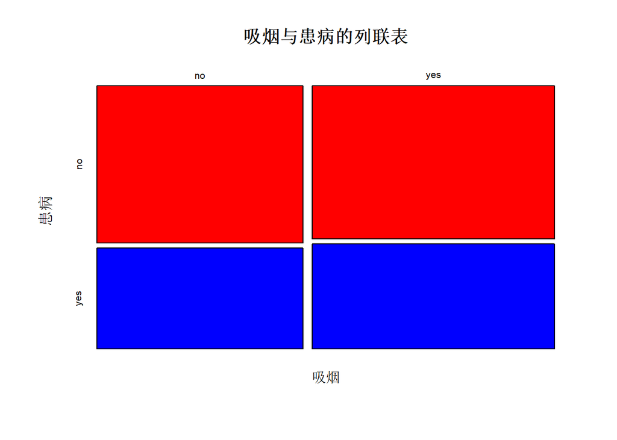

```r
mosaicplot(contingency_table, main = "吸烟与患病的列联表",
           xlab = '吸烟', ylab = '患病', col = c("red", "blue"))
```